# Youtube Feed Contents Creators Statistics

## Part 1: BoxPlots Of Hours by Total Subscribers and Total Views

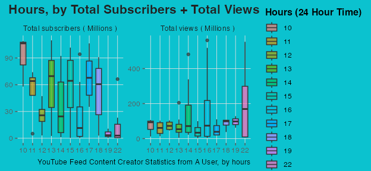

Hours, by Total subscribers, Total Views, key featues is the ordered categorical ‘hours’ as it was factored to display the hours in increased order, that also can be used as a function of hours, while being boxplots

From this Part 1 Plots, I had created two BoxPlots side by side, with the hours in 24 hour time, ( 10 am to 10pm), setting the hours as factor, plotting for Total Subscribers and Total views. From this, it easy to see any potential trends from left to right, as the hours increase. From above, there is not a seeming trend weather the total views nor subscribers of the contents from the feed have any relation with when, the feed is recorded. Rather it appears for a random results of Total subscribers and Views against hours.

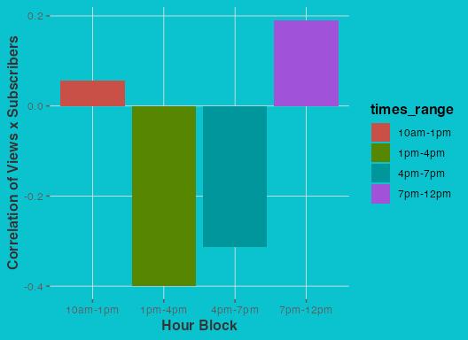

## Part 3: Scatter plots of Total Views against Total Subscribers by Hour Blocks, Animated.

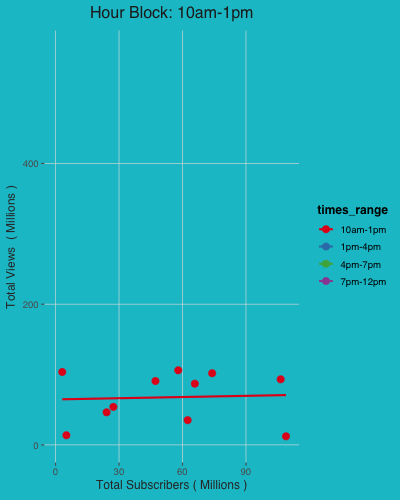

Part 3 Scatter plots, key features is the animated imagery of four scatter plots, with the time blocks ordered by time, adding the linear model for correlation view and values for the main variables, this for ease of summarising the conducted analyses.

For part 3 of this YouTube feed contents study, I had created four scatter plots of Total Subscribers by Total Views For each time block, WITH animation with transition for every plot. This was the display as to display all the above statistic conductions and findings from before with as scatter plot to CLEARLY see how high the values are for Total Subscribers and Views, AND the correlation with added linear function to the plots. As per time block, It is highly clear of all the summary statistics, with certain time blocks having higher views * subs values, while low correlations. From this I can signify a further analysis could be needed.